# Part I - (Ford GoBike System Data ExplORation 2025)

## Introduction

> This dataset contains information about bike-sharing system rides, specifically from February 2019. It includes details about users, such as age and gender, along with trip data such as the start and end points, stations, and trip durations. Additionally, it captures information on the type of user (customer or Subscriber).

## Preliminary Wrangling

```python
# import all packages and set plots to be embedded inline
import numpy as np
import pandas as pd
import matplotlib.pyplot as plt
import seaborn as sns

%matplotlib inline
sns.set_style('darkgrid')

import math
```

```python
# Dataset Loading
df= pd.read_csv('201902-fordgobike-tripdata.csv')
df.head(1)
```

|  | duration_sec | start_time | end_time | start_station_id | start_station_name | start_station_latitude | start_station_longitude | end_station_id | end_station_name | end_station_latitude | end_station_longitude | bike_id | user_type | member_birth_year | member_gender | bike_share_for_all_trip |
| --- | --- | --- | --- | --- | --- | --- | --- | --- | --- | --- | --- | --- | --- | --- | --- | --- |
| 0 | 52185 | 2019-02-28 17:32:10.1450 | 2019-03-01 08:01:55.9750 | 21.0 | Montgomery St BART Station (Market St at 2nd St) | 37.789625 | -122.400811 | 13.0 | Commercial St at Montgomery St | 37.794231 | -122.402923 | 4902 | Customer | 1984.0 | Male | No |

```python
#Dataset Structure
df.shape
```

```
(183412, 16)
```

```python
df.info()
```

```
<class 'pandas.core.frame.DataFrame'>
RangeIndex: 183412 entries, 0 to 183411
Data columns (total 16 columns):
 #   Column                   Non-Null Count   Dtype
---  ------                   --------------   -----
 0   duration_sec             183412 non-null  int64
 1   start_time               183412 non-null  object
 2   end_time                 183412 non-null  object
 3   start_station_id         183215 non-null  float64
 4   start_station_name       183215 non-null  object
 5   start_station_latitude   183412 non-null  float64
 6   start_station_longitude  183412 non-null  float64
 7   end_station_id           183215 non-null  float64
 8   end_station_name         183215 non-null  object
 9   end_station_latitude     183412 non-null  float64
 10  end_station_longitude    183412 non-null  float64
 11  bike_id                  183412 non-null  int64
 12  user_type                183412 non-null  object
 13  member_birth_year        175147 non-null  float64
 14  member_gender            175147 non-null  object
 15  bike_share_for_all_trip  183412 non-null  object
dtypes: float64(7), int64(2), object(7)
memory usage: 22.4+ MB
```

```python
#Check duplicates
df.duplicated().sum()
```

```
np.int64(0)
```

The all 183412 rows are unique.

Drop Nulls

```python
#Check nulls
df.isnull().sum()
```

```
duration_sec                  0
start_time                    0
end_time                      0
start_station_id            197
start_station_name          197
start_station_latitude        0
start_station_longitude       0
end_station_id              197
end_station_name            197
end_station_latitude          0
end_station_longitude         0
bike_id                       0
user_type                     0
member_birth_year          8265
member_gender              8265
bike_share_for_all_trip       0
dtype: int64
```

```python
df.dropna(inplace=True)
```

```python
df.shape
```

```
(174952, 16)
```

# Fixing Datatypes

```python
#Transform start and end time columns to datetime type
df['start_time'] = pd.to_datetime(df['start_time'])
df['end_time'] = pd.to_datetime(df['end_time'])
```

```python
#Transform columns of discrete values from float to int type
df['start_station_id'] = df['start_station_id'].astype('int16')
df['end_station_id'] = df['end_station_id'].astype('int16')
df['member_birth_year'] = df['member_birth_year'].astype(int)
```

Extracting Data

```python
#Extract weekday and monthday from the datetime columns

df['start_weekday']  = df['start_time'].dt.day_name()
df['start_monthday'] = df['start_time'].dt.day.astype('int8')
```

```python
#Divide the day into three times Morning, Afternoon and Night

df['start_hour']=df['start_time'].dt.hour.astype('int8')

df['day_sequence'] = 'Morning'
df.loc[(df['start_hour'] >= 12) & (df['start_hour'] < 18), 'day_sequence'] = 'Afternoon'
df.loc[(df['start_hour'] >= 18) & (df['start_hour'] <= 23), 'day_sequence'] = 'Night'
```

```python
df['end_hour']=df['end_time'].dt.hour.astype('int8')
```

```python
# Convert trip duration to minutes and hours
df['duration_minutes'] = (df['duration_sec']/60).round(2)
df['duration_hours'] = (df['duration_sec']/3600).round(2)
```

Calculations

```python
def calculate_distance(start_lat, start_lon, end_lat, end_lon):

    # Convert latitude and longitude from degrees to radians
    start_lat_rad = math.radians(start_lat)
    start_lon_rad = math.radians(start_lon)
    end_lat_rad = math.radians(end_lat)
    end_lon_rad = math.radians(end_lon)

    # Differences in coordinates
    delta_lat = end_lat_rad - start_lat_rad
    delta_lon = end_lon_rad - start_lon_rad

    # Haversine formula
    a = math.sin(delta_lat / 2)**2 + math.cos(start_lat_rad) * math.cos(end_lat_rad) * math.sin(delta_lon / 2)**2
    c = 2 * math.atan2(math.sqrt(a), math.sqrt(1 - a))

    # Radius of the Earth in kilometers
    R = 6371.0

    # Distance in kilometers
    distance = R * c
    return distance
```

```python
# Create a new column with the calculated traveled distance
df['distance'] = df.apply(
    lambda row: calculate_distance(
        row['start_station_latitude'],
        row['start_station_longitude'],
        row['end_station_latitude'],
        row['end_station_longitude']
    ), axis=1
)
```

```python
df['speed'] = (df['distance']/ df['duration_sec'])*1000  #m/s
df['speed'].head()
```

```
0    0.010438
2    0.043725
3    0.007145
4    1.520064
5    1.858451
Name: speed, dtype: float64
```

```python
#Calculate age from birth year for each member
df['age'] = (2025 - df['member_birth_year']).astype('int16')
df['age'].head()
```

```
0    41
2    53
3    36
4    51
5    66
Name: age, dtype: int16
```

Drop Unnecessary Data

```python
df['member_gender'].value_counts()
```

```
member_gender
Male      130500
Female     40805
Other       3647
Name: count, dtype: int64
```

Since the percentage of *others* to the total counts of members is 2% we can drop *others*.

```python
df.drop(df[df['member_gender']=='Other'].index, inplace= True)
```

```python
df.shape
```

```
(171305, 26)
```

```python
df.rename(columns={'member_gender' : 'gender'}, inplace=True)
```

```python
df['gender'].value_counts()
```

```
gender
Male      130500
Female     40805
Name: count, dtype: int64
```

```python
#drop unnecessary columns
df.drop(['start_time','end_time',
         'start_station_latitude', 'end_station_latitude', 'start_station_longitude', 'end_station_longitude',
         'member_birth_year']
        , axis=1 , inplace=True)
```

DataTypes Optimization

```python
#data type optimization

df['user_type'] = df['user_type'].astype('category')
df['gender'] = df['gender'].astype('category')
df['bike_share_for_all_trip'] = df['bike_share_for_all_trip'].astype('category')
```

```python
ordered_days = ['Monday', 'Tuesday', 'Wednesday', 'Thursday', 'Friday', 'Saturday', 'Sunday']
df['start_weekday'] = pd.Categorical(df['start_weekday'], categories=ordered_days, ordered=True)
```

```python
ordered_periods=['Morning', 'Afternoon', 'Night']
df['day_sequence'] = pd.Categorical(df['day_sequence'], categories=ordered_periods, ordered=True)
```

```python
df.info()
```

```
<class 'pandas.core.frame.DataFrame'>
Index: 171305 entries, 0 to 183411
Data columns (total 19 columns):
 #   Column                   Non-Null Count   Dtype
---  ------                   --------------   -----
 0   duration_sec             171305 non-null  int64
 1   start_station_id         171305 non-null  int16
 2   start_station_name       171305 non-null  object
 3   end_station_id           171305 non-null  int16
 4   end_station_name         171305 non-null  object
 5   bike_id                  171305 non-null  int64
 6   user_type                171305 non-null  category
 7   gender                   171305 non-null  category
 8   bike_share_for_all_trip  171305 non-null  category
 9   start_weekday            171305 non-null  category
 10  start_monthday           171305 non-null  int8
 11  start_hour               171305 non-null  int8
 12  day_sequence             171305 non-null  category
 13  end_hour                 171305 non-null  int8
 14  duration_minutes         171305 non-null  float64
 15  duration_hours           171305 non-null  float64
 16  distance                 171305 non-null  float64
 17  speed                    171305 non-null  float64
 18  age                      171305 non-null  int16
dtypes: category(5), float64(4), int16(3), int64(2), int8(3), object(2)
memory usage: 14.1+ MB
```

By optimizing data types, we reduced the dataset size from 22.4+ MB to 14.1+ MB, significantly decreasing memory usage and improving efficiency when handling this large dataset.

### What is the structure of your dataset?

> The dataset consists of 183,412 rows and 16 columns, which include both categorical data (nominal and ordinal) and quantitative data (continuous and discrete). Some columns have missing (null) values.

### What is/are the main feature(s) of interest in your dataset?

> The key features include trip duration, speed, distance travelled, and weekdays. Additionally, important features of interest are age, the trip start and end times, as well as the start and end station names.

### What features in the dataset do you think will help support your investigation into your feature(s) of interest?

> Some features are derived, while others already exist:
> - age
> - start_weekday
> - start_hour
> - day_sequence
> - start_station_name
> - duration_sec
> - speed
> - distance

## Univariate Exploration

```python
def draw_hist(dataframe,column_name, bins, unit):
    sns.histplot(data=dataframe, x=column_name, bins=bins);
    if '_' in column_name:
        unit = column_name.split('_')[1]
        column_name=column_name.split('_')[0]

    plt.xlabel(column_name.title()+ f" ({unit})") if unit else plt.xlabel(column_name.title())
    plt.ylabel('Count')
```

```python
def plot_hist(dataframe, column_name,binsize, x_min, x_max, unit=None, custom_title=None):
    bins = np.arange(0, dataframe[column_name].max()+binsize, binsize)

    plt.xlim(x_min, x_max)

    draw_hist(dataframe, column_name,bins, unit)
    plt.title(custom_title) if custom_title else plt.title(f"Distribution of {column_name.title()}")
```

```python
def Log_Transformation(dataframe,column_name, binsize, start, ticks, unit=None):
    bins= 10 ** np.arange(start, np.log10(dataframe[column_name].max()+ binsize), binsize)

    draw_hist(dataframe, column_name,bins, unit)

    plt.xscale('log')
    plt.xticks(ticks=ticks, labels=ticks)
    plt.title(f"Distribution of {column_name.title()} (Log Scale)")
```

```python
def countplot_withPercent(dataframe,column_name):
    # Create the count plot
    bars = sns.countplot(data=dataframe, x=column_name, order=dataframe[column_name].value_counts().index)

    # Calculate total count for percentage computation
    total = len(df)

    # Annotate bars with percentages
    for bar in bars.patches:  # Access the bars in the plot
        count = bar.get_height()  # Get the count (height of the bar)
        percentage = (count / total) * 100  # Calculate percentage
        # Place percentage text above the bar
        plt.text(bar.get_x() + bar.get_width() / 2, count, f'{percentage:.2f}%',
                ha='center', va='bottom', fontsize=10)

    if '_' in column_name:
        column_name=column_name.replace('_', ' ')

    plt.xlabel(column_name.title())
```

```python
def count_plot(data,x, order=None,hue=None,hue_order=None,palette=None,
                title=None, xlabel=None,ylabel=None, xticks_rotation=None,
                y_lim_min=None,y_lim_max=None, legend_n_col=None):
    sns.countplot(data=data, x=x, order=order,hue=hue, hue_order=hue_order, palette=palette);

    plt.title(title)

    plt.xlabel(xlabel)
    plt.xticks(rotation=xticks_rotation);

    plt.ylabel(ylabel)
    plt.ylim(y_lim_min,y_lim_max)

    if legend_n_col:
        plt.legend(ncol = legend_n_col);
```

### What is the distribution of Average Speed by each bike?

```python
grouped_bikes_speed=df.groupby('bike_id')['speed'].mean().reset_index()
grouped_bikes_speed
```

|  | bike_id | speed |
| --- | --- | --- |
| 0 | 11 | 3.157817 |
| 1 | 12 | 2.802828 |
| 2 | 13 | 2.914931 |
| 3 | 14 | 2.875290 |
| 4 | 15 | 3.013948 |
| ... | ... | ... |
| 4598 | 6635 | 3.230479 |
| 4599 | 6636 | 3.133678 |
| 4600 | 6638 | 2.772428 |
| 4601 | 6644 | 3.074327 |
| 4602 | 6645 | 3.232309 |

4603 rows × 2 columns

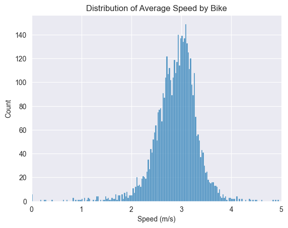

```python
plot_hist(grouped_bikes_speed, 'speed', 0.025, 0, 5, 'm/s','Distribution of Average Speed by Bike')
```

> The average speed of trips by bikes is around 3 m/s

### What is the distribution of member's age?

```python
df.drop(df[df['age']> 100].index, inplace= True)
```

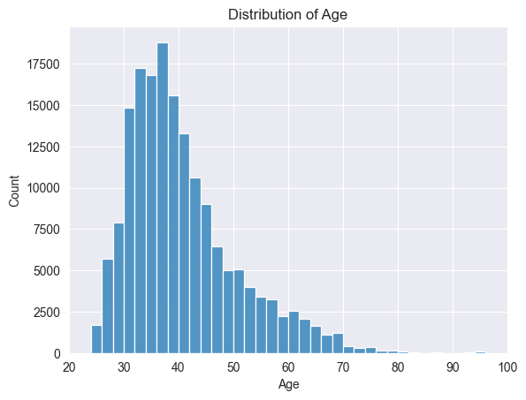

```python
plot_hist(df,'age', 2 , 20, 100)
```

> It is evident that the distribution of Age is right-skewed, with a noticeable number of members aged over 70 and 80. Considering questions about their physical abilities and whether they are capable of participating, further investigation is needed to determine whether these values should be excluded from the analysis.

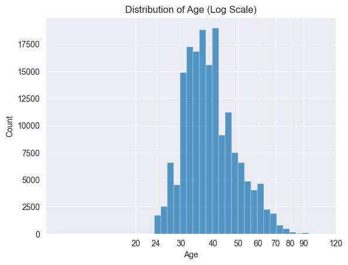

```python
Log_Transformation(df,'age', 0.025, 1 ,  [20,24, 30, 40, 50, 60, 70, 80, 90, 120])
```

### What is the distribution of Trip Duration?

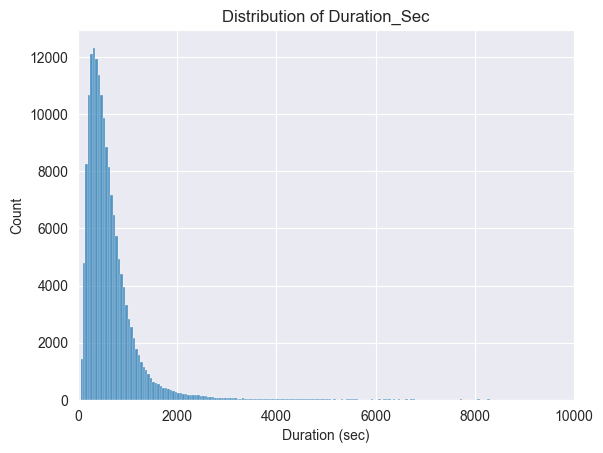

```python
plot_hist(df,'duration_sec', 50, 0, 10000)
```

```python
10** np.log10(df['duration_sec'].describe())
```

```
count    171231.000000
mean        697.779175
std        1577.564442
min          61.000000
25%         322.000000
50%         509.000000
75%         787.000000
max       84548.000000
Name: duration_sec, dtype: float64
```

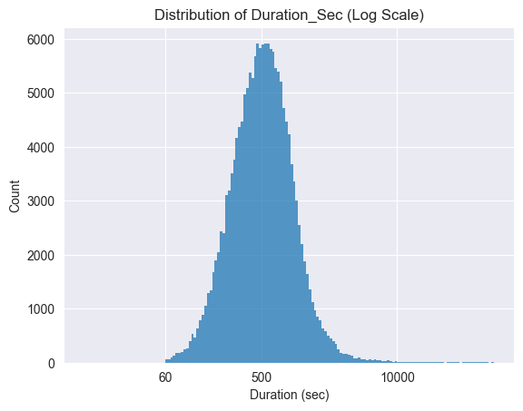

```python
Log_Transformation(df, 'duration_sec', 0.025, 1,  [60, 500, 10000])
```

> After plotting the data on a log scale, the duration peaks are concentrated within a range of 300 to 800 seconds, equivalent to 5 to 13 minutes. Additionally, there is strong evidence of values exceeding 10,000 seconds(2 Hours and 47 minutes). Further investigation is required to determine whether these are outliers or valid data points.

### What is the distribution of Distance?

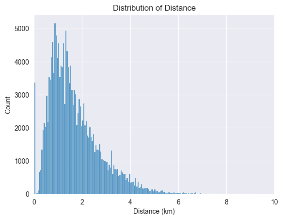

```python
plot_hist(df,'distance',0.05, 0, 10, 'km')
```

> How far was traveled on each trip? The analysis reveals that the majority of trips cover less than 10 km.

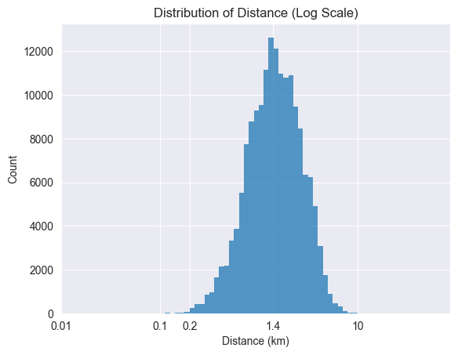

```python
Log_Transformation(df,'distance', 0.05, -1, [0.01, 0.1, 0.2, 1.4, 10], 'km')
```

> To enhance data visualization, we transformed the distance variable to a log scale, revealing that the peak distances range between 1 and 3 kilometers

### What is the member's gender distribution?

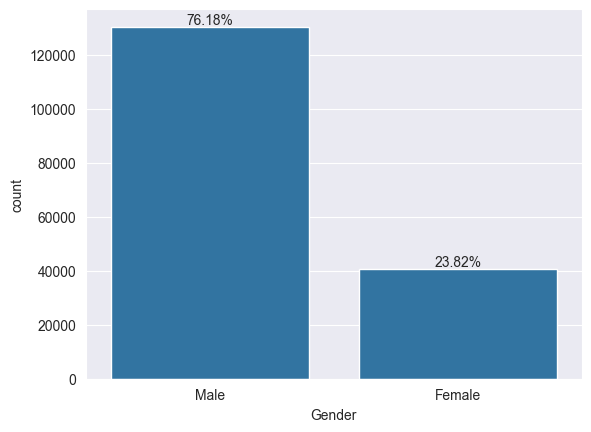

```python
countplot_withPercent(df, 'gender')
```

### How are the user types distributed?

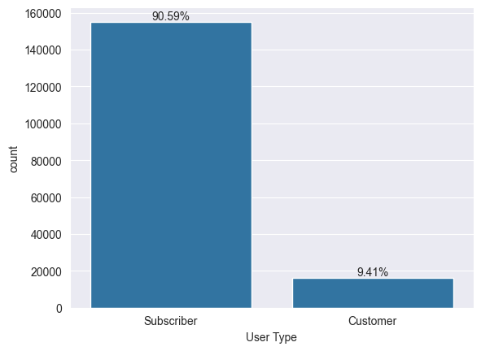

```python
countplot_withPercent(df, 'user_type')
```

> Approximately 91% of members are subscriber, highlighting their dominance over Customer category (9.41 %). This suggests that the majority prefer a subscription-based model, potentially due to cost-effectiveness or added benefits.

### What is the distribution of shared bikes?

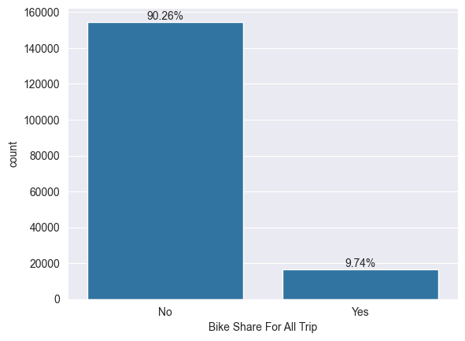

```python
countplot_withPercent(df, 'bike_share_for_all_trip')
```

> About 90% of bikes are not shared for all trips, indicating that the majority are used by individual riders rather than being available for multiple users.

### What is the distribution of Weekdays in February?

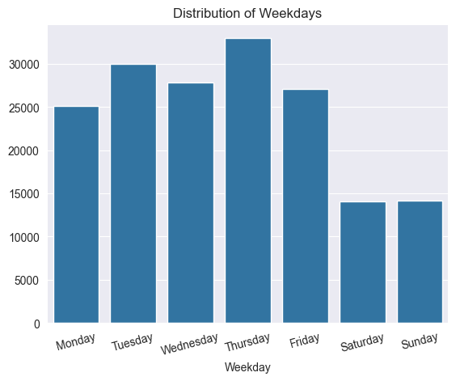

```python
count_plot(df,'start_weekday',ordered_days,title='Distribution of Weekdays',xlabel='Weekday',xticks_rotation=15)
```

> Thursdays have the highest number of bike trips, while Saturdays and Sundays, despite being weekends, have the fewest trips.

### What is the distribution of Start and End hours?

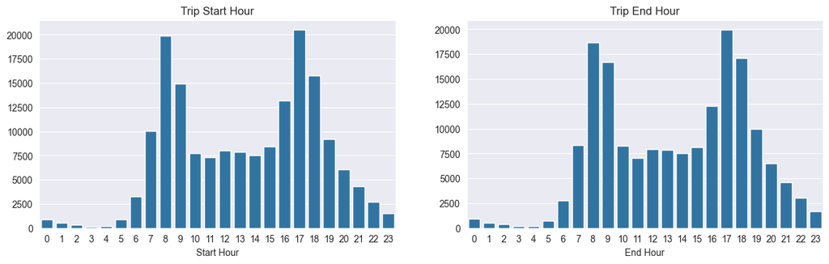

```python
plt.figure(figsize=[15,4])

plt.subplot(1,2,1)
count_plot(df,'start_hour',title='Trip Start Hour',xlabel='Start Hour')

plt.subplot(1,2,2)
count_plot(df,'end_hour',title='Trip End Hour',xlabel='End Hour',ylabel='')
```

> Most trips start and end during two peak rush hours: 8 AM in the morning and 5 PM in the afternoon. This pattern likely reflects commuting behavior, with people traveling to work or school in the morning and returning home in the evening.

### What is the distribution of Start Hour at February weekends and working Days?

```python
#Filtering the data to extract weekends and working days
df['weekend_or_working'] = df['start_weekday'].isin(["Saturday", "Sunday"])
working_days=df[df['weekend_or_working']==False]
weekend_days=df[df['weekend_or_working']==True]
```

```python
df['weekend_or_working'] = df['weekend_or_working'].replace({True: 'Weekend', False: 'Working'}).astype('category')
```

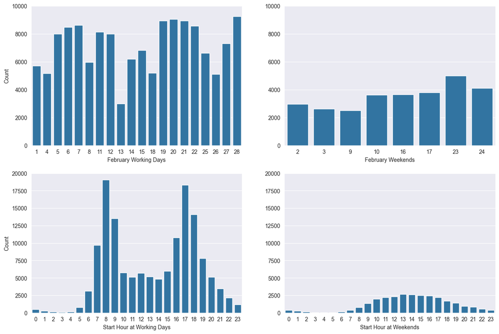

```python
plt.figure(figsize=[15,10])
plt.subplot(2,2,1)
count_plot(working_days,'start_monthday', xlabel='February Working Days', ylabel='Count', y_lim_min=0, y_lim_max=10000)

plt.subplot(2,2,2)
count_plot(weekend_days,'start_monthday', xlabel='February Weekends', y_lim_min=0, y_lim_max=10000)

plt.subplot(2,2,3)
count_plot(working_days,'start_hour',xlabel='Start Hour at Working Days',ylabel='Count', y_lim_min=0, y_lim_max=20000)

plt.subplot(2,2,4)
count_plot(weekend_days,'start_hour',xlabel='Start Hour at Weekends',y_lim_min=0, y_lim_max=20000)
```

> Saturday, February 23rd, the last Saturday of the month, recorded the highest number of bike trips. This could be due to increased recreational use or more people taking advantage of the weekend to use bike-sharing services.

> The frequency of starting hours on weekends is highest between 10 AM and 5 PM, with 1 PM being the most frequent starting hour. This pattern suggests that people are likely using bikes for recreational purposes during midday and afternoon hours on weekends.

### How are trips distributed across different times of the day?

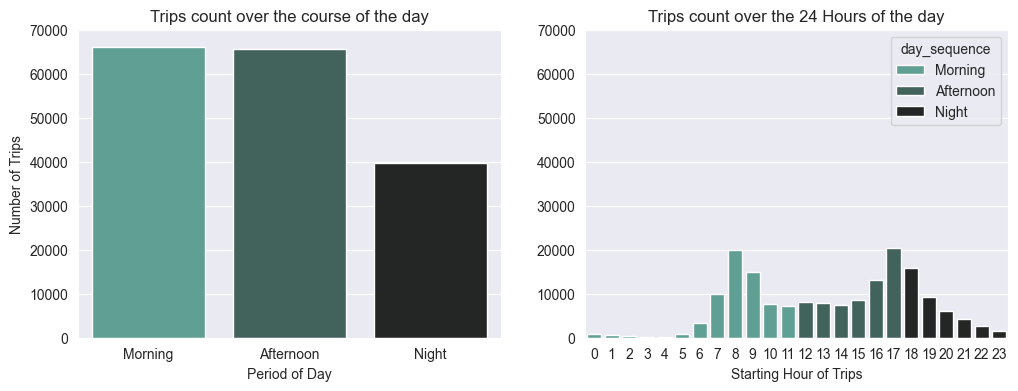

```python
plt.figure(figsize=[12,4])
plt.subplot(1,2,1)
count_plot(df, 'day_sequence',order= ordered_periods, hue='day_sequence', hue_order=ordered_periods, palette='dark:#5A9_r',
            title='Trips count over the course of the day', xlabel='Period of Day',ylabel='Number of Trips',
            y_lim_min=0, y_lim_max=70000)

plt.subplot(1,2,2)
plt.ylim(0,70000);
count_plot(df, 'start_hour', hue='day_sequence', hue_order=ordered_periods, palette='dark:#5A9_r',
            title='Trips count over the 24 Hours of the day', xlabel='Starting Hour of Trips',ylabel='',
            y_lim_min=0, y_lim_max=70000)
```

> Morning and afternoon have the highest and similar frequency of trips during the day. This trend likely corresponds to rush hours.

### What are the top ten starting and ending stations?

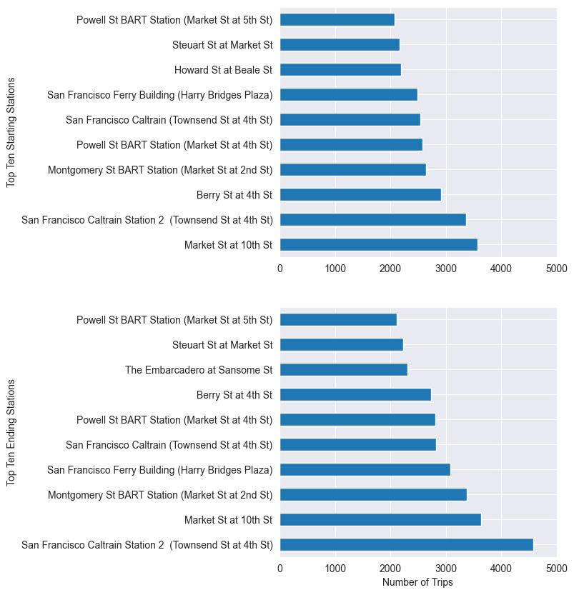

```python
plt.figure(figsize=[5,10])

plt.subplot(2,1,1)
df['start_station_name'].value_counts().iloc[:10].plot(kind='barh')
plt.xlabel('')
plt.ylabel('Top Ten Starting Stations')
plt.xlim(0,5000)

plt.subplot(2,1,2)
df['end_station_name'].value_counts().iloc[:10].plot(kind='barh')
plt.xlabel('Number of Trips')
plt.ylabel('Top Ten Ending Stations');
plt.xlim(0,5000);
```

> The top ten starting and ending stations highlight the most frequented locations, suggesting key commuting hubs or popular areas for bike usage.

### Which group has the highest percentage of non-sharing bike users among subscribers?

```python
df['grouped_categories'] = df['gender'].astype(str) + " | " + df['user_type'].astype(str)+" | " + df['bike_share_for_all_trip'].astype(str)
```

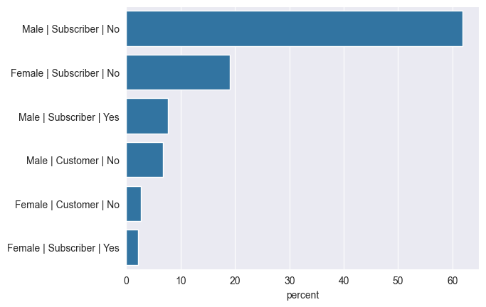

```python
sns.countplot(data=df, y='grouped_categories', stat='percent', order=df['grouped_categories'].value_counts().index);
plt.ylabel('');
```

> Among the different grouped categories, male subscribers who do not use sharing bikes have the highest percentage.

### Discuss the distribution(s) of your variable(s) of interest. Were there any unusual points? Did you need to perform any transformations?

> The variables of interest, such as duration, distance, and age, exhibit right-skewed distributions. To improve data visualization and achieve a clearer normal distribution, a log transformation was applied. This transformation allowed for better definition of data ranges and the identification of potential outliers for further investigation.

> In addition, other variables were considered, such as average speed, which does not require transformation. The analysis also covered the number of trips across weekdays, months, and periods of the day.

> I also examined the categorical data related to participants, including gender and user type distributions, as well as the bike share program and the most frequent starting and ending stations.

### Of the features you investigated, were there any unusual distributions? Did you perform any operations on the data to tidy, adjust, or change the form of the data? If so, why did you do this?

> Several data wrangling steps were performed after assessing the dataset:
> 1. **Data Cleaning**:
> - All null values were removed.
> - An outlier distance of 69 km was removed.
> - Outlier ages above 100 years were removed.
> 2. **Data Type Transformation**:
> - Columns containing discrete values were converted from float to integer, as ids and birth-year
> - Timestamp columns were transformed into datetime format to extract necessary information.
> - Categorical columns were converted from string to category data type.
> - Ordinal data was categorized according to its natural order to ensure consistency in visualizations.
> 3. **Feature Engineering**:
> - New variables were derived for easier analysis, such as age (calculated from the birth year) and distance (calculated from latitude and longitude data). Speed was also computed.
> - Additional features were extracted for further analysis, including the day of the month, day of the week, and start time information (starting hour). The starting hour was categorized into three main periods of the day.

## Bivariate Exploration

```python
def multi_variate_hist_2d(dataframe,column_x,column_y,bins_x,bins_y,column_bar):
    # Determine which bin for each point
    column_x_bins = pd.cut(dataframe[column_x], bins_x, right=False,
                        include_lowest=False, labels=False).astype(int)
    column_y_bins = pd.cut(dataframe[column_y], bins_y, right=False,
                        include_lowest=False, labels=False).astype(int)

    # Count the points in each bin
    n_points = dataframe.groupby([column_x_bins, column_y_bins]).size()
    n_points = n_points.reset_index().pivot(index = column_x, columns = column_y).values

    column_bar_weights = dataframe[column_bar] / n_points[column_x_bins, column_y_bins]
    h2d = plt.hist2d(data=dataframe, x=column_x, y=column_y,  cmin=0.5, cmap='viridis_r',  bins=[bins_x, bins_y],
                    weights=column_bar_weights)
    return h2d
```

```python
def add_text_annotations(counts,dark_value,bins_x,bins_y,bin_x_i,bin_y_j,cmap_colors):
    if cmap_colors=='viridis':
        dark_threshold_text_color='black'
        light_threshold_text_color='white'
    elif cmap_colors=='viridis_r':
        dark_threshold_text_color='white'
        light_threshold_text_color='black'

    # Loop through the cell counts and add text annotations for each
    for i in range(counts.shape[0]):
        for j in range(counts.shape[1]):
            c = counts[i,j]
            if c >= dark_value: # increase visibility on darker cells
                plt.text(bins_x[i]+bin_x_i, bins_y[j]+bin_y_j, int(c),
                        ha = 'center', va = 'center', color = dark_threshold_text_color)
            elif c > 0:
                plt.text(bins_x[i]+bin_x_i, bins_y[j]+bin_y_j, int(c),
                        ha = 'center', va = 'center', color = light_threshold_text_color)
```

```python
def plot_hist_2d(dataframe,bins_x,bins_y,column_x, column_y, cmap_colors, ticks_x, dark_value, bin_x_i, bin_y_j,
                  unit_x=None,unit_y=None,column_bar=None, unit_bar=None,figsize=None):
    if figsize:
        plt.figure(figsize=figsize)

    if column_bar:
        h2d=multi_variate_hist_2d(dataframe, column_x, column_y, bins_x, bins_y, column_bar)
        cbar=plt.colorbar()
        if '_' in column_bar:
            unit_bar=column_bar.split('_')[1]
            column_bar=column_bar.split('_')[0]
        cbar.set_label(column_bar.title()+f" ({unit_bar})") if unit_bar else cbar.set_label(column_bar.title())
    else:
        h2d = plt.hist2d(data=dataframe, x=column_x, y=column_y,  cmin=0.5, cmap=cmap_colors, bins=[bins_x, bins_y])
        plt.colorbar()

    if '_' in column_x: column_x = column_x.replace('_',' ')
    if '_' in column_y:
        unit_y= column_y.split('_')[1]
        column_y = column_y.split('_')[0]

    plt.xlabel(column_x.title()+f" ({unit_x})") if unit_x else plt.xlabel(column_x.title())
    plt.ylabel(column_y.title()+f" ({unit_y})") if unit_y else plt.ylabel(column_y.title())

    labels_x = [f'{v}' for v in ticks_x]
    plt.xticks(ticks_x, labels_x)

    counts = h2d[0]
    add_text_annotations(counts,dark_value,bins_x,bins_y, bin_x_i,bin_y_j,cmap_colors)
```

```python
def draw_point_plot(data,x,y,order,title,y_lim_min,y_lim_max,unit):
    sns.pointplot(data=data, x=x, y=y, order=order , err_kws={'linewidth': 0})

    if '_' in y:
        unit=y.split('_')[1]
        y=y.split('_')[0]

    title=f'Average Trips {y.title()} across the {title}'
    plt.title(title)
    plt.xlabel('')
    plt.ylabel(y.title()+ f" ({unit})")
    plt.ylim(y_lim_min, y_lim_max)
```

```python
def point_plot(data,y, y_lim_min=None,y_lim_max=None,unit=None):
    plt.figure(figsize=[15,4])
    plt.subplot(1,2,1)
    draw_point_plot(data=data, x='day_sequence', y=y, order=ordered_periods,
                    title='day',y_lim_min=y_lim_min,y_lim_max=y_lim_max,unit=unit)

    plt.subplot(1,2,2)
    draw_point_plot(data=data, x='start_weekday', y=y, order=ordered_days,
                    title='weeday',y_lim_min=y_lim_min,y_lim_max=y_lim_max,unit=unit)
```

```python
def user_type_plot(bi_var=None,multi_var=None):
    plt.figure(figsize=(10,5))
    user_type_color={'Customer': sns.color_palette('dark:#5A9_r')[0], 'Subscriber':sns.color_palette('dark:#5A9_r')[2]}
    if bi_var:
        sns.countplot(data=df, x='start_weekday', hue='user_type', palette=user_type_color)
    elif multi_var:
        sns.barplot(data = df, x = 'start_weekday', y = 'duration_minutes', hue = 'user_type', order=ordered_days, palette=user_type_color)
        plt.ylabel('Duration (minutes)')

    plt.legend(loc = 0, ncol = 3, framealpha = 1, title = 'User Type')
    plt.xlabel('')
```

What is the Participation Rate of Men and Women in the Bike-Sharing Program?

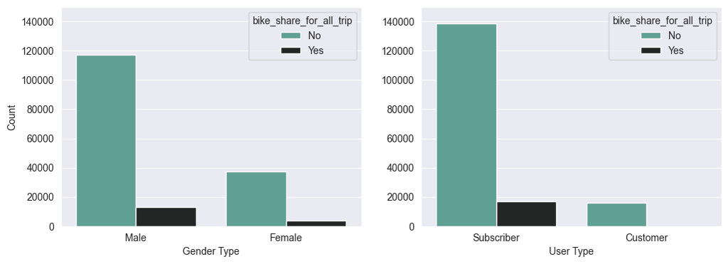

```python
plt.figure(figsize=[12,4])

plt.subplot(1,2,1)
count_plot(data= df, x='gender',order=df['gender'].value_counts().index, hue='bike_share_for_all_trip', palette='dark:#5A9_r',
           xlabel='Gender Type',ylabel='Count',
           y_lim_min=0,y_lim_max=150000)

plt.subplot(1,2,2)
count_plot(data= df, x='user_type',order=df['user_type'].value_counts().index, hue='bike_share_for_all_trip', palette='dark:#5A9_r',
           xlabel='User Type',ylabel='',
           y_lim_min=0,y_lim_max=150000)
```

> The graphs show that the majority of both men and women do not participate in the bike-sharing program.  
> Most individuals are subscribers rather than customers, as customers do not participate in bike-sharing.

What is the Correlation between Weekend/Working Days and Start Hour?

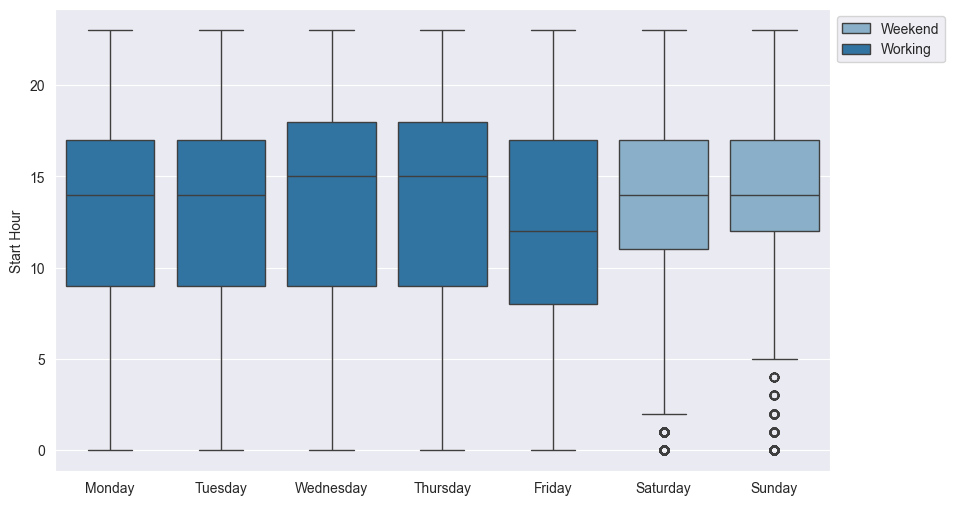

```python
plt.figure(figsize=(10, 6))
colors = {'Working': sns.color_palette()[0], 'Weekend':sns.color_palette('Set3')[4]}
sns.boxplot(data=df, x='start_weekday', y='start_hour', order=ordered_days, hue='weekend_or_working', palette=colors);
plt.legend(loc='upper left', bbox_to_anchor=(1, 1))
plt.xlabel('');
plt.ylabel('Start Hour');
```

The start times primarily cluster around 2 PM and 3 PM. On working days, start times tend to be earlier, around 8-9 AM. On weekends, there is significant activity around noon. This variation suggests that weekend trips may be more leisure-oriented, while weekday trips are more structured around typical working hours.

### What are the Trends in Trip Duration, Speed, and Distance Across Weekdays and Weekends?

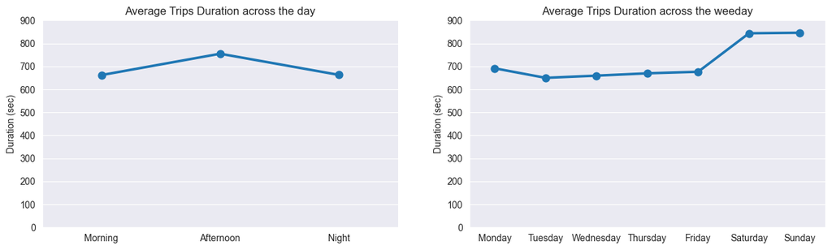

```python
point_plot(data=df,y='duration_sec',y_lim_min=0,y_lim_max=900)
```

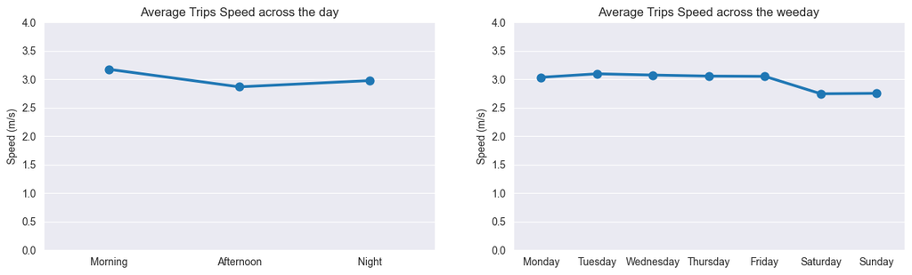

```python
point_plot(data=df,y='speed',y_lim_min=0,y_lim_max=4,unit='m/s')
```

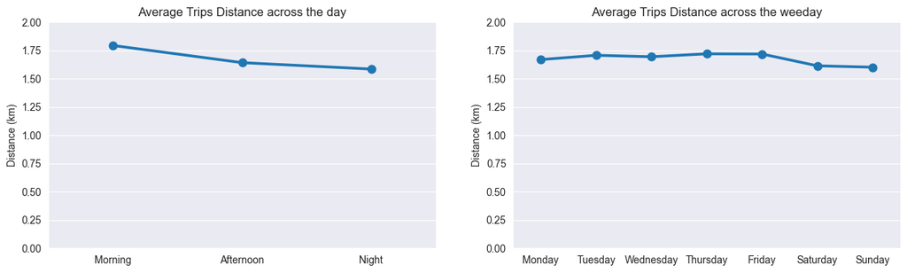

```python
point_plot(data=df,y='distance', y_lim_min=0,y_lim_max=2,unit='km')
```

> Afternoon has a slightly higher average trip duration, which could be attributed to increased traffic. Although Thursday records the highest count of trips, Saturday and Sunday show higher average trip durations compared to working days.

> Average trip speed is slightly lower in the afternoon, correlating with heavier traffic, with weekends also showing reduced speeds.

> Mornings see the highest average distances, while nights have the shortest distances but faster speeds due to lighter traffic. In contrast, afternoons are marked by longer durations but slower speeds, possibly due to increased traffic or leisurely outings.

### How do Trip Patterns Vary between Weekdays and Weekends?

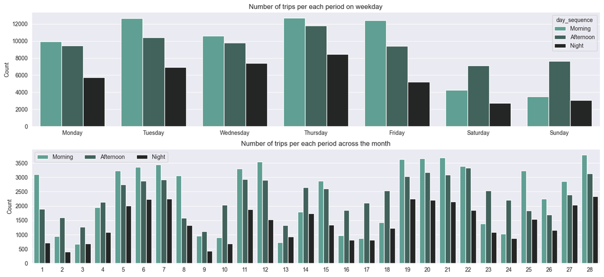

```python
plt.figure(figsize=[18,8])

plt.subplot(2,1,1)
count_plot(data=df, x='start_weekday', hue='day_sequence',order=ordered_days, hue_order=ordered_periods, palette='dark:#5A9_r',
           title='Number of trips per each period on weekday', xlabel='',ylabel='Count')

plt.subplot(2,1,2)
count_plot(data=df, x='start_monthday', hue='day_sequence', hue_order=ordered_periods, palette='dark:#5A9_r',
           title='Number of trips per each period across the month', xlabel='',ylabel='Count',legend_n_col=3)
```

Most trips occur in the morning on working days, while the highest number of trips takes place in the afternoon on weekends.

### What is the Relationship between Distance and Duration?

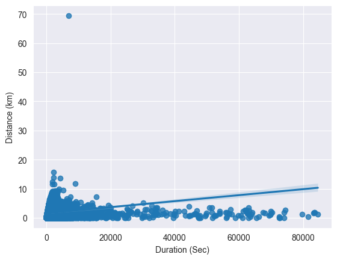

```python
sns.regplot(data=df,x='duration_sec', y='distance');
plt.xlabel('Duration (Sec)')
plt.ylabel('Distance (km)');
```

```python
df[df.distance>20]
```

|  | duration_sec | start_station_id | start_station_name | end_station_id | end_station_name | bike_id | user_type | gender | bike_share_for_all_trip | start_weekday | ... | start_hour | day_sequence | end_hour | duration_minutes | duration_hours | distance | speed | age | weekend_or_working | grouped_categories |
| --- | --- | --- | --- | --- | --- | --- | --- | --- | --- | --- | --- | --- | --- | --- | --- | --- | --- | --- | --- | --- | --- |
| 112038 | 6945 | 21 | Montgomery St BART Station (Market St at 2nd St) | 300 | Palm St at Willow St | 4780 | Subscriber | Female | No | Tuesday | ... | 14 | Afternoon | 16 | 115.75 | 1.93 | 69.469241 | 10.00277 | 40 | Working | Female \| Subscriber \| No |

1 rows × 21 columns

one outlier row, so we can drop it.

```python
df.shape
```

```
(171231, 21)
```

```python
df.drop(df[df['distance']>20].index, inplace=True)
```

```python
df.shape
```

```
(171230, 21)
```

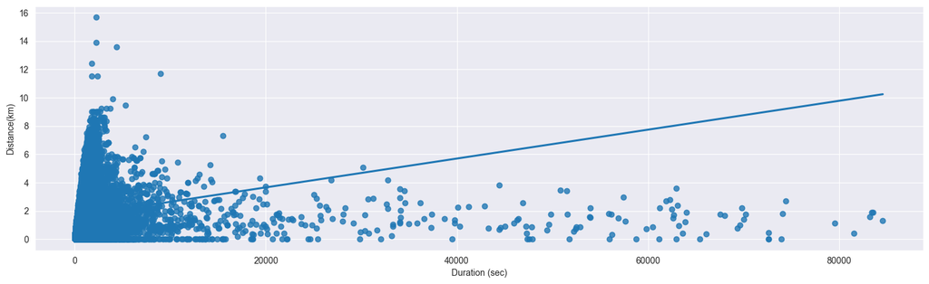

```python
# Plot regression plot between duration and distance
plt.figure(figsize = [18, 5])
sns.regplot(data=df,x='duration_sec', y='distance', ci=None);
plt.xlabel('Duration (sec)')
plt.ylabel('Distance(km)');
```

This graph illustrates a positive relationship between trip distance and duration, meaning that as the distance of a trip increases, the duration also tends to increase.

### How are Subscription Types Distributed by Gender in Bike Share Usage?

```python
# Use group_by() and size() to get the combination of the number of members from each different gender and user type:
combined_categories = df.groupby(['gender', 'user_type'],observed=True).size().reset_index(name='count')
combined_categories
```

|  | gender | user_type | count |
| --- | --- | --- | --- |
| 0 | Female | Customer | 4622 |
| 1 | Female | Subscriber | 36168 |
| 2 | Male | Customer | 11489 |
| 3 | Male | Subscriber | 118951 |

```python
# Use DataFrame.pivot() to rearrange the data, to have vehicle class on rows
combined_categories = combined_categories.pivot(index='gender', columns='user_type', values='count')
combined_categories
```

| user_type gender | Customer | Subscriber |
| --- | --- | --- |
| Female | 4622 | 36168 |
| Male | 11489 | 118951 |

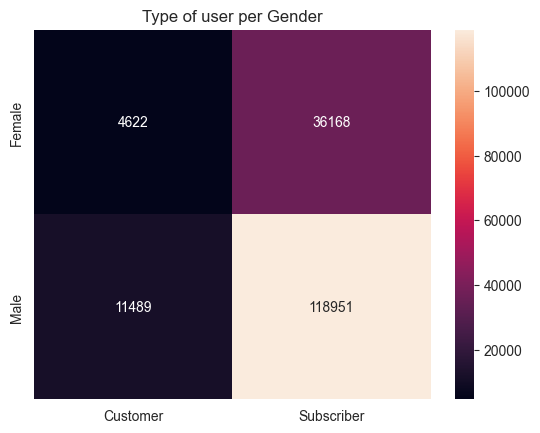

```python
#Plot the heatmap
sns.heatmap(combined_categories,annot=True, fmt='d' );
plt.title("Type of user per Gender")
plt.xlabel('');
plt.ylabel('');
```

The heatmap reveals a significant gender disparity, with more males participating than females. Additionally, the data indicates that the number of subscribers is consistently greater than the number of customers across all genders, highlighting a clear preference for the subscription-based model.

### How do Customers and Subscribers differ in Bike Share Usage across the Week?

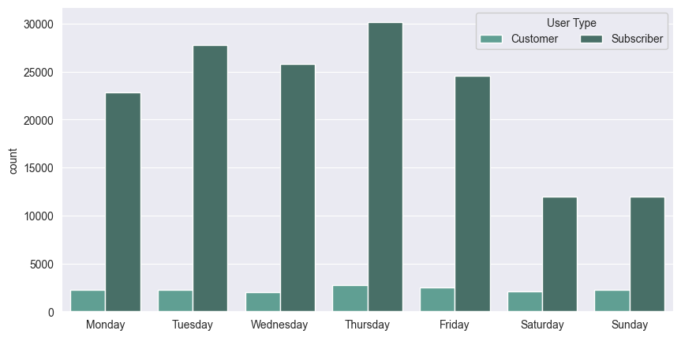

```python
user_type_plot(bi_var=True)
```

> The number of subscribers significantly outweighs the number of customers on all days of the week.

> Subscriber activity peaks on Thursday and decreases on weekends, indicating that their usage is likely tied to workday commuting.

### Is there a Relationship between Member Age and Trip Speed?

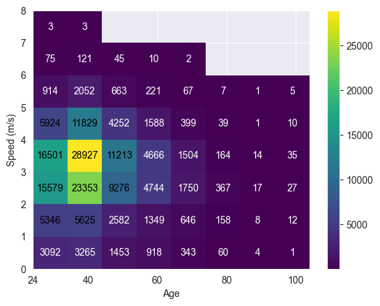

```python
plot_hist_2d(df,bins_x=np.arange(24, 100+10, 10),bins_y=np.arange(0, 8+1, 1),column_x='age', column_y='speed',
            cmap_colors='viridis', ticks_x=[24,40,60,80,100], dark_value=5000, bin_x_i=5, bin_y_j=0.5,
            unit_y='m/s')
```

> Members aged 30-40 exhibit the highest frequency, with an average speed of 3-4 m/s. Speed shows a clear age dependency, peaking in physical activity between 34 and 44 years, followed by a gradual decline as age progresses. For those aged 80 and above, the frequency of observations significantly decreases, with speeds generally falling below 4 m/s.

### How are Trip Durations Affected by Age?

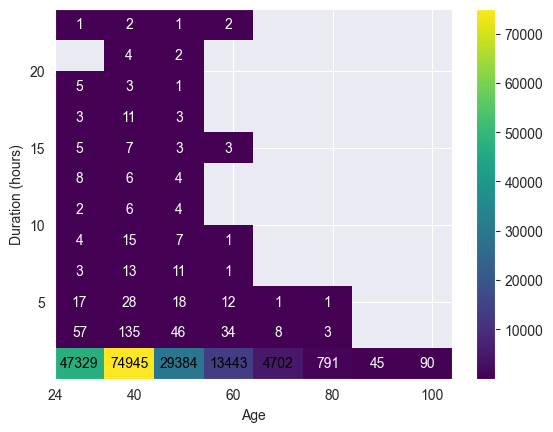

```python
plot_hist_2d(df,np.arange(24, 100+10, 10),np.arange(0.02, 24+2, 2), 'age','duration_hours','viridis',
            [24,40,60,80,100], 800, 5,1)
```

> This plot highlights an age-dependent pattern, where younger and middle-aged individuals tend to be more active, with participation decreasing as age increases. Shorter durations are more prevalent across all age groups.

### How do Time of Day and Speed influence the frequency of Bike Trips?

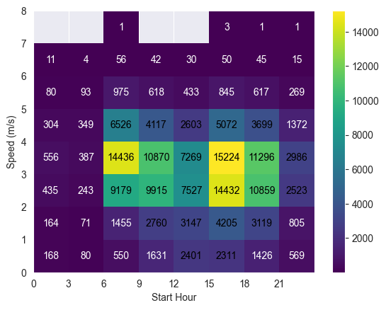

```python
plot_hist_2d(df,np.arange(0, 23+3, 3),np.arange(0, 8+1, 1), 'start_hour','speed','viridis',
            ticks_x=[0,3,6,9,12,15,18,21], dark_value=2000, bin_x_i=1.5,bin_y_j=0.5,unit_y='m/s')
```

> The heatmap shows that peak frequencies occur at specific times, especially during rush hours, which align with typical activity patterns. The highest frequency is observed between 15:00-18:00 with speeds ranging from 3-4 m/s, while another peak occurs from 06:00-09:00 within the same speed range. Additionally, a notable frequency rise is seen between 06:00-09:00 at speeds of 2-3 m/s, suggesting higher activity levels during both morning and evening rush hours.

> Lower frequencies are typically observed at higher speeds (6-8 m/s) and in the early morning hours (00:00-03:00), indicating reduced activity during these periods.

### How do Time of Day and Trip Duration influence the frequency of Bike Trips?

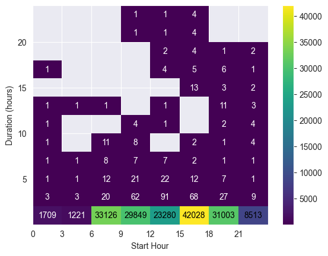

```python
plot_hist_2d(df,np.arange(0, 23+3, 3),np.arange(0.02, 24+2, 2), 'start_hour','duration_hours','viridis',
            ticks_x=[0,3,6,9,12,15,18,21], dark_value=2000, bin_x_i=1.5,bin_y_j=1,unit_y='hours')
```

> Durations under 5 hours are common across all starting hours. Longer durations (>15 hours) are uncommon, with only a few trips lasting beyond 15 hours.

> The frequency of durations exceeding 2 hours is particularly low, especially between 00:00 and 06:00 AM.

### How do Time of Day and Trip Distance influence the frequency of Bike Trips?

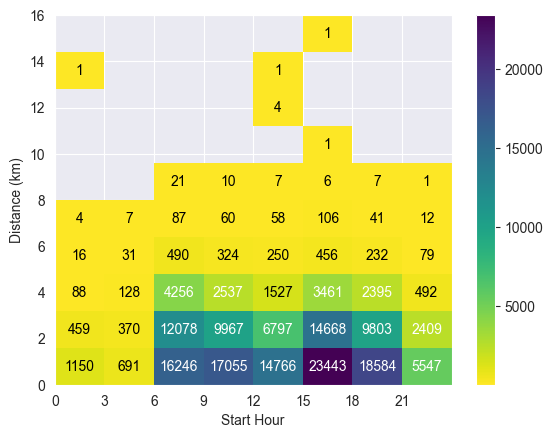

```python
plot_hist_2d(df,np.arange(0, 23+3, 3),np.arange(0, 16+1.6, 1.6), 'start_hour','distance','viridis_r',
            ticks_x=[0,3,6,9,12,15,18,21], dark_value=2000, bin_x_i=1.5,bin_y_j=0.8,unit_y='km')
```

> High frequencies are concentrated between 06:00 and 21:00, particularly for distances under 3 km, suggesting a preference for shorter trips during these active hours.

> As distances extend beyond 10 km, the frequency drops significantly, while shorter distances (under 4 km) show higher values.